# tutorials_bcm_2024_analysis_demo_ipynb

## Installing requirements

The cell below installs every Python package needed to run this notebook, at fully pinned versions, using [`uv`](https://github.com/astral-sh/uv) for fast resolution. In Colab the cell is collapsed by default — click the ▶ button to run it.

```python
# install cell skipped during CI (deps preinstalled into system Python)
```

> **⚠️ Restart runtime after install**

> The install may upgrade packages already loaded in the kernel. Go to **Runtime → Restart session**, then **Run all cells below** (skip this install cell on re-run).

# Streaming and interacting with NWB data from DANDI

First, let's import a few classes. If you are *not* running this notebook on DANDI Hub, you will need to install these packages using `pip` or your favorite Python package manager. For example:

```
pip install dandi pynwb fsspec requests aiohttp matplotlib pynapple seaborn
```

```python
from dandi.dandiapi import DandiAPIClient
import fsspec
from fsspec.implementations.cached import CachingFileSystem
import h5py
import matplotlib.pyplot as plt
import numpy as np
import pynwb
```

The data used in this tutorial were used in this publication: [Sargolini, et al. "Conjunctive representation of position, direction, and velocity in entorhinal cortex." Science 312.5774 (2006): 758-762](https://www.science.org/doi/10.1126/science.1125572). The data can be found on the DANDI Archive in [Dandiset 000582](https://dandiarchive.org/dandiset/000582).

```python
dandiset_id = "000582"
filepath = "sub-10073/sub-10073_ses-17010302_behavior+ecephys.nwb"
with DandiAPIClient() as client:
    asset = client.get_dandiset(dandiset_id, 'draft').get_asset_by_path(filepath)
    s3_url = asset.get_content_url(follow_redirects=1, strip_query=True)
```

```python
s3_url
```

```
'https://dandiarchive.s3.amazonaws.com/blobs/26a/22c/26a22c31-09bc-43a4-9187-edc7394ed12c'
```

There are multiple methods to stream NWB files. We currently recommend fsspec, but additional options are described in the [pynwb streaming tutorial](https://pynwb.readthedocs.io/en/stable/tutorials/advanced_io/streaming.html).

```python
# create a virtual http filesystem with local caching
fs = CachingFileSystem(
    fs=fsspec.filesystem("http"),
    cache_storage="nwb-cache",  # local folder for the cache
)
```

```python
# open the file using the S3 URL
f = fs.open(s3_url, "rb")
file = h5py.File(f)
io = pynwb.NWBHDF5IO(file=file)
nwbfile = io.read()
```

You can print the `NWBFile` object in a Jupyter notebook to get a simplified, interactive representation of the contents of the NWB file.

```python
nwbfile
```

root (NWBFile)

session_description: This session includes spike and position times for recorded cells from a Long Evans rat that was running in a 1 x 1 meter enclosure. The cells were recorded in the dorsocaudal 25% portion of the medial entorhinal cortex (MEC).Position is given for two LEDs to enable calculation of head direction.

identifier: 294b7de1-a624-44d8-b1a1-28028dd2cf0c

**session_start_time**

1900-01-01 00:00:00+01:00

**timestamps_reference_time**

1900-01-01 00:00:00+01:00

**file_create_date**

**0**

2023-09-16 15:50:09.775622+02:00

**experimenter**

('Sargolini, Francesca',)

**related_publications**

('https://doi.org/10.1126/science.1125572',)

**acquisition**

**ElectricalSeries (ElectricalSeries)**

starting_time: 0.0

rate: 4800.0

resolution: -1.0

comments: no comments

description: The EEG signals from one electrode amplified 8000-10000 times, lowpass-filtered at 500 Hz (single pole), and stored at 4800 Hz (16 bits/sample).

conversion: 1e-06

offset: 0.0

unit: volts

**data**

HDF5 dataset

| Data type | float64 |
| --- | --- |
| Shape | (2880000,) |
| Array size | 21.97 MiB |
| Chunk shape | (5625,) |
| Compression | gzip |
| Compression opts | 4 |
| Uncompressed size (bytes) | 23040000 |
| Compressed size (bytes) | 14520596 |
| Compression ratio | 1.5867117300143878 |

starting_time_unit: seconds

**electrodes (DynamicTableRegion)**

description: all electrodes

**table (ElectrodesTable)**

description: metadata about extracellular electrodes

**columns**

**location**

the location of channel within the subject e.g. brain region

**group**

a reference to the ElectrodeGroup this electrode is a part of

**group_name**

the name of the ElectrodeGroup this electrode is a part of

**table**

| id | location | group | group_name |
| --- | --- | --- | --- |
| 0 | MEC | ElectrodeGroup pynwb.ecephys.ElectrodeGroup at 0x139798816667840\nFields:\n description: The name of the ElectrodeGroup this electrode is a part of.\n device: EEG pynwb.device.Device at 0x139798816666… | ElectrodeGroup |

**keywords**

HDF5 dataset

| Data type | object |
| --- | --- |
| Shape | (3,) |
| Array size | 24.00 bytes |
| Chunk shape | None |
| Compression | None |
| Compression opts | None |
| Uncompressed size (bytes) | 24 |
| Compressed size (bytes) | 48 |
| Compression ratio | 0.5 |

['medial entorhinal cortex' 'spike times' 'position']

**processing**

**behavior (ProcessingModule)**

description: Processed behavioral data.

**Position (Position)**

**SpatialSeriesLED1 (SpatialSeries)**

resolution: -1.0

comments: no comments

description: Position (x, y) for the first tracking LED.

conversion: 0.01

offset: 0.0

unit: meters

**data**

HDF5 dataset

| Data type | float64 |
| --- | --- |
| Shape | (30000, 2) |
| Array size | 468.75 KiB |
| Chunk shape | (1875, 1) |
| Compression | gzip |
| Compression opts | 4 |
| Uncompressed size (bytes) | 480000 |
| Compressed size (bytes) | 453899 |
| Compression ratio | 1.0575039821634329 |

**timestamps**

HDF5 dataset

| Data type | float64 |
| --- | --- |
| Shape | (30000,) |
| Array size | 234.38 KiB |
| Chunk shape | (1875,) |
| Compression | gzip |
| Compression opts | 4 |
| Uncompressed size (bytes) | 240000 |
| Compressed size (bytes) | 68370 |
| Compression ratio | 3.5103115401491882 |

timestamps_unit: seconds

interval: 1

reference_frame: (0,0) is not known.

**ecephys (ProcessingModule)**

description: Processed electrical series data.

**LFP (LFP)**

**ElectricalSeriesLFP (ElectricalSeries)**

starting_time: 0.0

rate: 250.0

resolution: -1.0

comments: no comments

description: The EEG signals from one electrode stored at 250 Hz.

conversion: 1e-06

offset: 0.0

unit: volts

**data**

HDF5 dataset

| Data type | float64 |
| --- | --- |
| Shape | (150000,) |
| Array size | 1.14 MiB |
| Chunk shape | (2344,) |
| Compression | gzip |
| Compression opts | 4 |
| Uncompressed size (bytes) | 1200000 |
| Compressed size (bytes) | 294856 |
| Compression ratio | 4.069783216214017 |

starting_time_unit: seconds

**electrodes (DynamicTableRegion)**

description: all electrodes

**table (ElectrodesTable)**

description: metadata about extracellular electrodes

**columns**

**location**

the location of channel within the subject e.g. brain region

**group**

a reference to the ElectrodeGroup this electrode is a part of

**group_name**

the name of the ElectrodeGroup this electrode is a part of

**table**

| id | location | group | group_name |
| --- | --- | --- | --- |
| 0 | MEC | ElectrodeGroup pynwb.ecephys.ElectrodeGroup at 0x139798816667840\nFields:\n description: The name of the ElectrodeGroup this electrode is a part of.\n device: EEG pynwb.device.Device at 0x139798816666… | ElectrodeGroup |

**electrodes (ElectrodesTable)**

description: metadata about extracellular electrodes

**columns**

**location**

the location of channel within the subject e.g. brain region

**group**

a reference to the ElectrodeGroup this electrode is a part of

**group_name**

the name of the ElectrodeGroup this electrode is a part of

**table**

| id | location | group | group_name |
| --- | --- | --- | --- |
| 0 | MEC | ElectrodeGroup pynwb.ecephys.ElectrodeGroup at 0x139798816667840\nFields:\n description: The name of the ElectrodeGroup this electrode is a part of.\n device: EEG pynwb.device.Device at 0x139798816666… | ElectrodeGroup |

**electrode_groups**

**ElectrodeGroup (ElectrodeGroup)**

description: The name of the ElectrodeGroup this electrode is a part of.

location: MEC

**device (Device)**

description: The device used to record EEG signals.

**devices**

**EEG (Device)**

description: The device used to record EEG signals.

**subject (Subject)**

age: P3M/P5M

age__reference: birth

description: A Long Evans rat.

sex: M

species: Rattus norvegicus

subject_id: 10073

weight: 0.35/0.45

**units (Units)**

description: Autogenerated by NWBFile

waveform_unit: volts

**columns**

**unit_name**

The identifier of the cell, based on tetrode number and cell number.

**spike_times**

the spike times for each unit

**histology**

The layer of MEC of the grid cell.

**hemisphere**

Indicates which hemisphere the electrodes were inserted above MEC.

**depth**

Indicates the depth of the inserted electrodes in meters.

**table**

| id | unit_name | spike_times | histology | hemisphere | depth |
| --- | --- | --- | --- | --- | --- |
| 0 | t1c1 | [0.7903958333333333, 0.794, 0.8111666666666667, 0.8313541666666666, 0.9217708333333333, 1.0205208333333333, 1.3573020833333334, 1.6583229166666666, 1.6768645833333333, 2.7457708333333333, 4.0086979166… | MEC LII |  | 0.0024 |
| 1 | t2c1 | [1.0451354166666667, 1.7003854166666668, 2.3154375, 11.046822916666667, 14.239729166666667, 14.822927083333333, 14.837010416666667, 19.281322916666667, 19.585395833333333, 19.603958333333335, 19.71908… | MEC LII |  | 0.0024 |
| 2 | t2c3 | [0.18273958333333334, 0.5340729166666667, 0.5707291666666666, 0.7023333333333334, 0.7242604166666666, 0.7670520833333333, 0.88084375, 1.06084375, 1.1815, 1.2828333333333333, 1.2922916666666666, 1.4162… | MEC LII |  | 0.0024 |
| 3 | t3c1 | [1.0358229166666666, 1.04803125, 1.6964270833333333, 1.7780416666666667, 1.7842083333333334, 1.8619166666666667, 1.8659375, 1.879125, 1.8885416666666666, 1.9763333333333333, 2.0486666666666666, 2.1341… | MEC LII |  | 0.0024 |

... and 4 more row(s).

experiment_description: The sample includes conjunctive cells and head direction cells from layers III and V of medial entorhinal cortex and have been published in Sargolini et al. (Science, 2006).

session_id: 17010302

lab: Moser

institution: Centre for the Biology of Memory, Norwegian University of Science and Technology

Access `nwbfile.subject` to get information about the subject used in this experiment, including their age, sex, species, and ID. Age uses the ISO 8601 standard for time durations - `P3M` corresponds to 3 months old, and `P3M/P5M` means the subject was between 3-5 months old.

```python
nwbfile.subject
```

subject (Subject)

age: P3M/P5M

age__reference: birth

description: A Long Evans rat.

sex: M

species: Rattus norvegicus

subject_id: 10073

weight: 0.35/0.45

Now let's access the position of the animal, which is stored in a `SpatialSeries` object at this particular path within the NWB file.

```python
position = nwbfile.processing["behavior"]["Position"]["SpatialSeriesLED1"]
position
```

SpatialSeriesLED1 (SpatialSeries)

resolution: -1.0

comments: no comments

description: Position (x, y) for the first tracking LED.

conversion: 0.01

offset: 0.0

unit: meters

**data**

HDF5 dataset

| Data type | float64 |
| --- | --- |
| Shape | (30000, 2) |
| Array size | 468.75 KiB |
| Chunk shape | (1875, 1) |
| Compression | gzip |
| Compression opts | 4 |
| Uncompressed size (bytes) | 480000 |
| Compressed size (bytes) | 453899 |
| Compression ratio | 1.0575039821634329 |

**timestamps**

HDF5 dataset

| Data type | float64 |
| --- | --- |
| Shape | (30000,) |
| Array size | 234.38 KiB |
| Chunk shape | (1875,) |
| Compression | gzip |
| Compression opts | 4 |
| Uncompressed size (bytes) | 240000 |
| Compressed size (bytes) | 68370 |
| Compression ratio | 3.5103115401491882 |

timestamps_unit: seconds

interval: 1

reference_frame: (0,0) is not known.

## Lazy loading of datasets

Data arrays are read passively from the NWB file. Accessing the `data` attribute of the `SpatialSeries` object does not read the data values, but presents an `h5py.Dataset` object that can be indexed to read data. You can use the `[:]` operator to read the entire data array into memory.

```python
position.data
```

```
<HDF5 dataset "data": shape (30000, 2), type "<f8">
```

```python
pos_data = position.data[:]
pos_data
```

```
array([[-0.4427946 , 17.10393108],
       [-0.4427946 , 17.10393108],
       [ 1.26778258, 16.85956291],
       ...,
       [ 2.00088708,  6.84046804],
       [ 2.00088708,  6.84046804],
       [ 0.77904624,  4.64115453]])
```

## Slicing datasets

Especially with very large datasets, it is often preferable to read only a portion of the data. To do this, index or slice into the `data` attribute just like if you were indexing or slicing a numpy array.

Let's get the X coordinates of the subject for all timestamps and get the timestamps.

```python
x = position.data[:,0]
x
```

```
array([-0.4427946 , -0.4427946 ,  1.26778258, ...,  2.00088708,
        2.00088708,  0.77904624])
```

```python
ts = position.timestamps[:]
ts
```

```
array([0.0000e+00, 2.0000e-02, 4.0000e-02, ..., 5.9994e+02, 5.9996e+02,
       5.9998e+02])
```

Now let's use those values to plot the X position of the subject over time. All times in NWB are stored in seconds relative to the session start time.

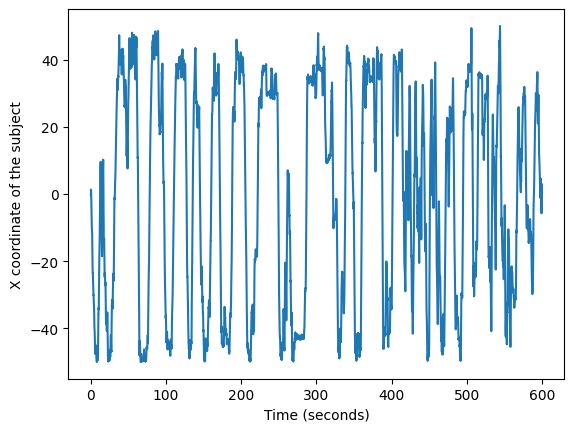

```python
plt.plot(ts, x)
plt.xlabel("Time (seconds)")
plt.ylabel("X coordinate of the subject");
```

We can also slice in the time dimension. Let's plot the (x, y) position of the subject for the first 100 time points.

```
[Text(0.5, 0, 'X coordinate'), Text(0, 0.5, 'Y coordinate')]
```

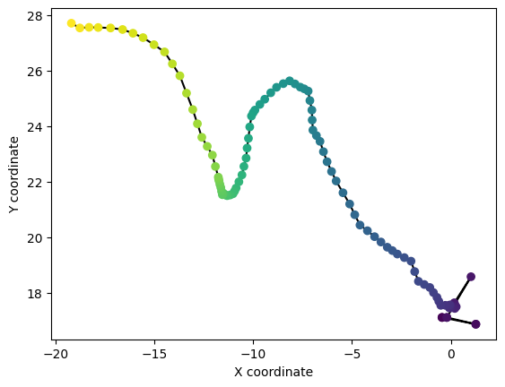

```python
time_indices = slice(0, 100)
fig, ax = plt.subplots()
ax.scatter(position.data[time_indices,0], position.data[time_indices,1], c=position.timestamps[time_indices])
ax.plot(position.data[time_indices,0], position.data[time_indices,1], color='k', zorder=0)
ax.set(xlabel="X coordinate", ylabel="Y coordinate")
```

## Access single unit data

Data and metadata about sorted single units are stored in a `Units` object. It stores metadata about each single unit in a tabular form, where each row represents a unit with spike times and additional metadata.

```python
nwbfile.units
```

units (Units)

description: Autogenerated by NWBFile

waveform_unit: volts

**columns**

**unit_name**

The identifier of the cell, based on tetrode number and cell number.

**spike_times**

the spike times for each unit

**histology**

The layer of MEC of the grid cell.

**hemisphere**

Indicates which hemisphere the electrodes were inserted above MEC.

**depth**

Indicates the depth of the inserted electrodes in meters.

**table**

| id | unit_name | spike_times | histology | hemisphere | depth |
| --- | --- | --- | --- | --- | --- |
| 0 | t1c1 | [0.7903958333333333, 0.794, 0.8111666666666667, 0.8313541666666666, 0.9217708333333333, 1.0205208333333333, 1.3573020833333334, 1.6583229166666666, 1.6768645833333333, 2.7457708333333333, 4.0086979166… | MEC LII |  | 0.0024 |
| 1 | t2c1 | [1.0451354166666667, 1.7003854166666668, 2.3154375, 11.046822916666667, 14.239729166666667, 14.822927083333333, 14.837010416666667, 19.281322916666667, 19.585395833333333, 19.603958333333335, 19.71908… | MEC LII |  | 0.0024 |
| 2 | t2c3 | [0.18273958333333334, 0.5340729166666667, 0.5707291666666666, 0.7023333333333334, 0.7242604166666666, 0.7670520833333333, 0.88084375, 1.06084375, 1.1815, 1.2828333333333333, 1.2922916666666666, 1.4162… | MEC LII |  | 0.0024 |
| 3 | t3c1 | [1.0358229166666666, 1.04803125, 1.6964270833333333, 1.7780416666666667, 1.7842083333333334, 1.8619166666666667, 1.8659375, 1.879125, 1.8885416666666666, 1.9763333333333333, 2.0486666666666666, 2.1341… | MEC LII |  | 0.0024 |

... and 4 more row(s).

We can view the single unit data as a pandas `DataFrame`.

```python
units_df = nwbfile.units.to_dataframe()
units_df
```

| id | unit_name | spike_times | histology | hemisphere | depth |
| --- | --- | --- | --- | --- | --- |
| 0 | t1c1 | [0.7903958333333333, 0.794, 0.8111666666666667... | MEC LII |  | 0.0024 |
| 1 | t2c1 | [1.0451354166666667, 1.7003854166666668, 2.315... | MEC LII |  | 0.0024 |
| 2 | t2c3 | [0.18273958333333334, 0.5340729166666667, 0.57... | MEC LII |  | 0.0024 |
| 3 | t3c1 | [1.0358229166666666, 1.04803125, 1.69642708333... | MEC LII |  | 0.0024 |
| 4 | t3c2 | [2.43025, 2.4398333333333335, 3.17965625, 3.39... | MEC LII |  | 0.0024 |
| 5 | t3c3 | [2.1157708333333334, 2.425427083333333, 3.3630... | MEC LII |  | 0.0024 |
| 6 | t3c4 | [0.07945833333333334, 2.244947916666667, 3.173... | MEC LII |  | 0.0024 |
| 7 | t4c1 | [2.4301666666666666, 2.439770833333333, 3.1795... | MEC LII |  | 0.0024 |

To access the spike times of the first single unit, index this pandas dataframe with the column name, “spike_times”, and the row index, 0. All times in NWB are stored in seconds relative to the session start time.

```python
units_df["spike_times"][0]
```

```
array([  0.79039583,   0.794     ,   0.81116667, ..., 595.28703125,
       595.53125   , 599.68578125])
```

We can use these spike times to generate raster plots of single unit activity over time.

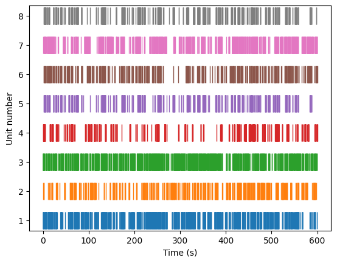

```python
fig, ax = plt.subplots()
for i, st in enumerate(units_df['spike_times']):
    ax.plot(st, np.ones_like(st) + i, '|', markersize=20)
    ax.set(xlabel='Time (s)', ylabel='Unit number')
```

We can also inspect the columns of the `Units` table for useful metadata such as descriptions of the values of each column.

```python
nwbfile.units["depth"].description
```

```
'Indicates the depth of the inserted electrodes in meters.'
```

# Using [Pynapple](https://pynapple-org.github.io/pynapple/) for data analysis

[Pynapple](https://pynapple-org.github.io/pynapple/) is a light-weight python library for neurophysiological data analysis that accepts NWB files as input.

Let's import pynapple and seaborn, set some seaborn plotting parameters, and load the streamed NWB file into Pynapple by creating a `nap.NWBFile` object using the `pynwb.NWBFile` object that we created earlier from `io.read()`.

```python
import pynapple as nap
import seaborn as sns

custom_params = {"axes.spines.right": False, "axes.spines.top": False}
sns.set_theme(style="ticks", palette="colorblind", font_scale=1.5, rc=custom_params)

nwb = nap.NWBFile(nwbfile)

nwb
```

```
17010302
┍━━━━━━━━━━━━━━━━━━━━━┯━━━━━━━━━━┑
│ Keys                │ Type     │
┝━━━━━━━━━━━━━━━━━━━━━┿━━━━━━━━━━┥
│ units               │ TsGroup  │
│ ElectricalSeriesLFP │ Tsd      │
│ SpatialSeriesLED1   │ TsdFrame │
│ ElectricalSeries    │ Tsd      │
┕━━━━━━━━━━━━━━━━━━━━━┷━━━━━━━━━━┙
```

We can load the sorted units as a pynapple `TsGroup` for inspection.

```python
units = nwb["units"]
units
```

```
  Index     rate  unit_name    histology    hemisphere      depth
-------  -------  -----------  -----------  ------------  -------
      0  2.93217  t1c1         MEC LII                          0
      1  1.50193  t2c1         MEC LII                          0
      2  2.57878  t2c3         MEC LII                          0
      3  1.13186  t3c1         MEC LII                          0
      4  1.29356  t3c2         MEC LII                          0
      5  1.35857  t3c3         MEC LII                          0
      6  2.8855   t3c4         MEC LII                          0
      7  1.46525  t4c1         MEC LII                          0
```

We can also load the position data, which is a pynapple `TsdFrame`.

```python
position = nwb["SpatialSeriesLED1"]
position
```

```
Time (s)                     x         y
-------------------  ---------  --------
0.0                  -0.442795  17.1039
0.01999999999998181  -0.442795  17.1039
0.03999999999996362   1.26778   16.8596
0.05999999999994543   1.26778   16.8596
0.08000000000004093  -0.198426  17.1039
0.10000000000002274  -0.198426  17.1039
0.12000000000000455   1.02341   18.5701
...
599.86                2.97836    4.39679
599.88                2.97836    4.39679
599.9                 2.24526    4.88552
599.92                2.24526    4.88552
599.9399999999999     2.00089    6.84047
599.9599999999999     2.00089    6.84047
599.9799999999999     0.779046   4.64115
dtype: float64, shape: (30000, 2)
```

Next, let's compute the 2d tuning curves and plot them.

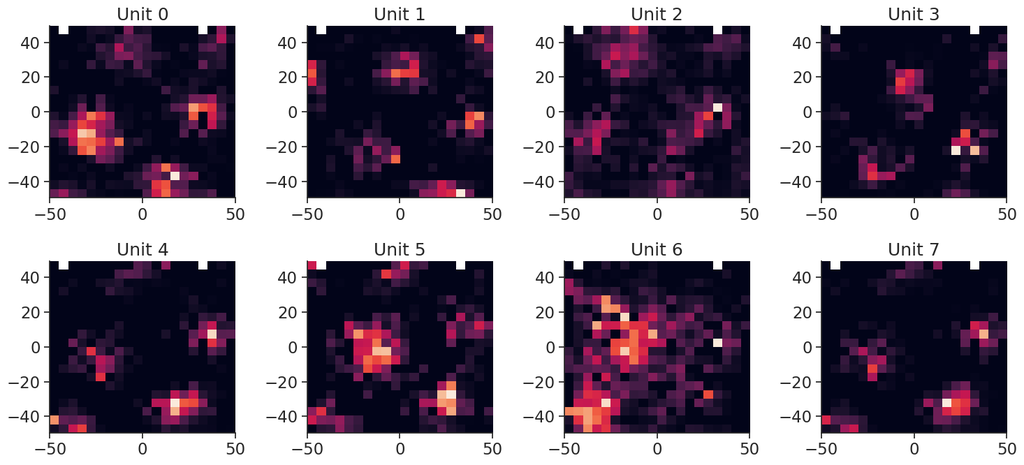

```python
tc, binsxy = nap.compute_2d_tuning_curves(units, position, 20)

extent = (
    np.min(position["x"]),
    np.max(position["x"]),
    np.min(position["y"]),
    np.max(position["y"]),
)

plt.figure(figsize=(15, 7))
for i in tc.keys():
    plt.subplot(2, 4, i + 1)
    plt.imshow(tc[i], origin="lower", extent=extent, aspect="auto")
    plt.title("Unit {}".format(i))
plt.tight_layout()
plt.show()
```

Finally, let's plot the spikes of unit 1, which has a nice grid. Let's use the function `value_from` to assign to each spike the closest position in time.

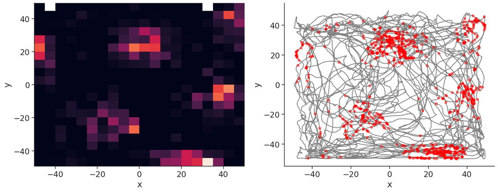

```python
plt.figure(figsize=(15, 6))
plt.subplot(121)
plt.imshow(tc[1], origin="lower", extent=extent, aspect="auto")
plt.xlabel("x")
plt.ylabel("y")

plt.subplot(122)
plt.plot(position["y"], position["x"], color="grey")
spk_pos = units[1].value_from(position)
plt.plot(spk_pos["y"], spk_pos["x"], "o", color="red", markersize=5, alpha=0.5)
plt.xlabel("x")
plt.ylabel("y")
plt.tight_layout()
plt.show()
```

It is good practice to close any open file and IO objects when you are done working with them so that they can be modified by other processes.

```python
io.close()
file.close()
f.close()
```